# Spotify Data Analysis Report

Rui Huang

2020-12-07

# Introduction

# Exploratory Data Analysis

Before diving into the analysis, we are going to take a glimpse at summary statistics and the distributions of the features for tracks and artists.

Let’s start with the tracks. Below is the summary statistics for the tracks data:

```
##  track_popularity  danceability        energy          loudness
##  Min.   : 0.00    Min.   :0.0000   Min.   :0.0000   Min.   :-49.531
##  1st Qu.:37.00    1st Qu.:0.4450   1st Qu.:0.4570   1st Qu.:-10.459
##  Median :48.00    Median :0.5710   Median :0.6740   Median : -7.185
##  Mean   :46.91    Mean   :0.5593   Mean   :0.6334   Mean   : -8.526
##  3rd Qu.:59.00    3rd Qu.:0.6920   3rd Qu.:0.8530   3rd Qu.: -5.041
##  Max.   :99.00    Max.   :0.9930   Max.   :1.0000   Max.   :  1.893
##   speechiness       acousticness     instrumentalness      liveness
##  Min.   :0.00000   Min.   :0.00000   Min.   :0.000000   Min.   :0.0000
##  1st Qu.:0.03590   1st Qu.:0.01405   1st Qu.:0.000000   1st Qu.:0.0959
##  Median :0.04880   Median :0.16100   Median :0.000133   Median :0.1270
##  Mean   :0.08784   Mean   :0.31405   Mean   :0.173020   Mean   :0.2038
##  3rd Qu.:0.08630   3rd Qu.:0.59800   3rd Qu.:0.115000   3rd Qu.:0.2580
##  Max.   :0.96300   Max.   :0.99600   Max.   :1.000000   Max.   :0.9950
##     valence           tempo          duration_s
##  Min.   :0.0000   Min.   :  0.00   Min.   :8.213s
##  1st Qu.:0.2440   1st Qu.: 98.74   1st Qu.:184.379s (~3.07 minutes)
##  Median :0.4490   Median :121.83   Median :223.039s (~3.72 minutes)
##  Mean   :0.4656   Mean   :121.72   Mean   :237.857286939508s (~3.96 minutes)
##  3rd Qu.:0.6790   3rd Qu.:140.05   3rd Qu.:271.6735s (~4.53 minutes)
##  Max.   :1.0000   Max.   :219.45   Max.   :4719.013s (~1.31 hours)
```

From above, on average, a track has the track popularity of around 50 and each track lasts for about 4 minutes. Most of features look quite normal based on the difference between their median and mean values. Let’s conduct a correlation analysis.

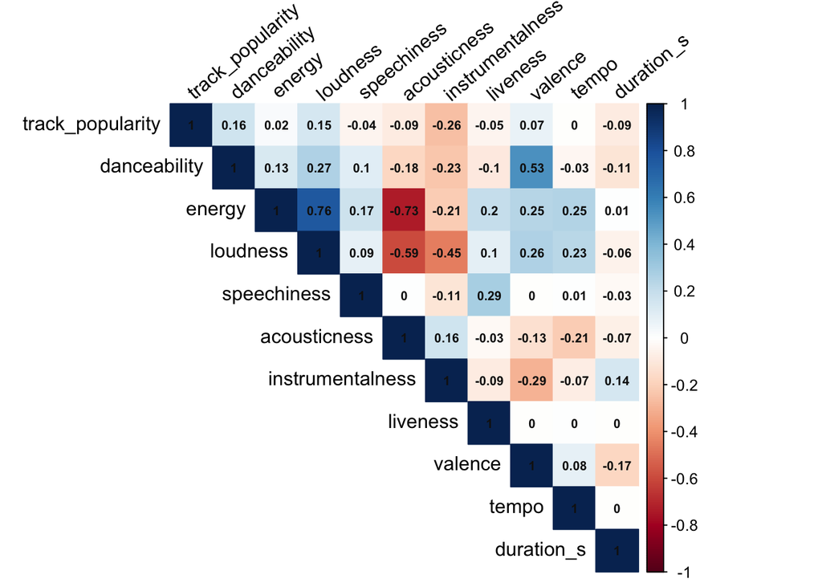

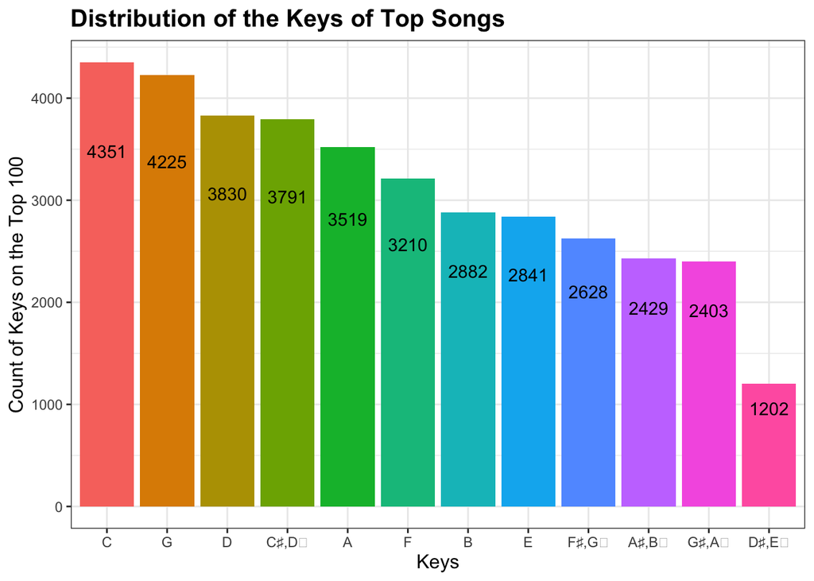

We see that the most popular key is C, followed by G. Throughout years, people’s music tastes have been changing. But how constantly? Let’s take a look. The graphs below shows the distributions of some audio features per year in the last decade.

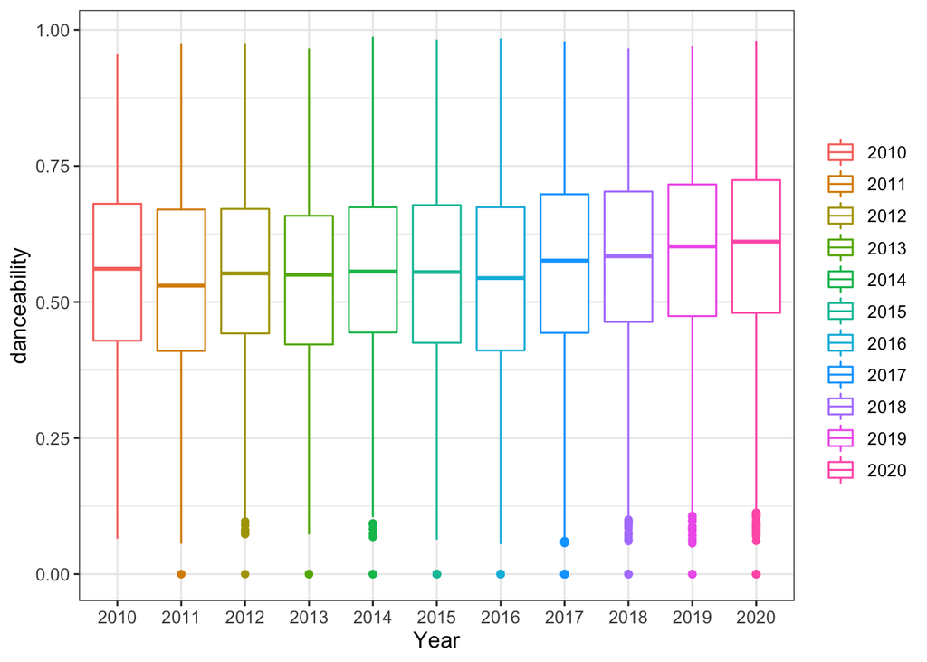

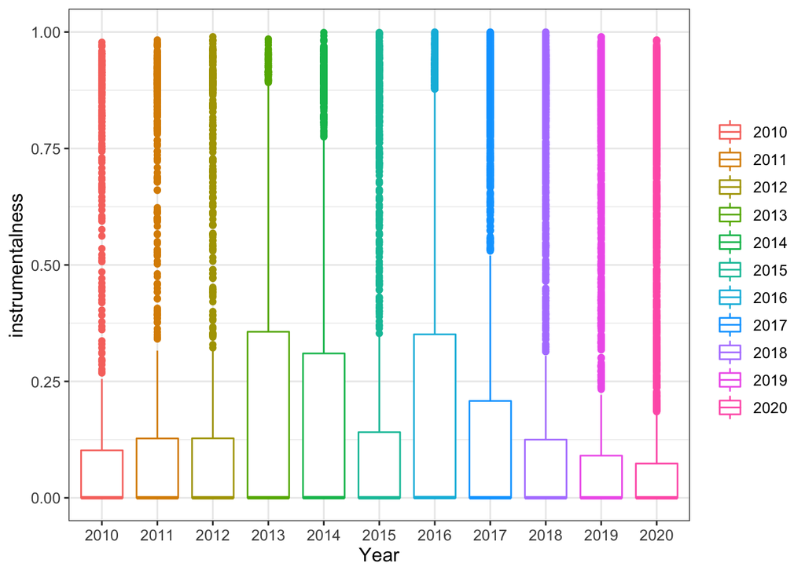

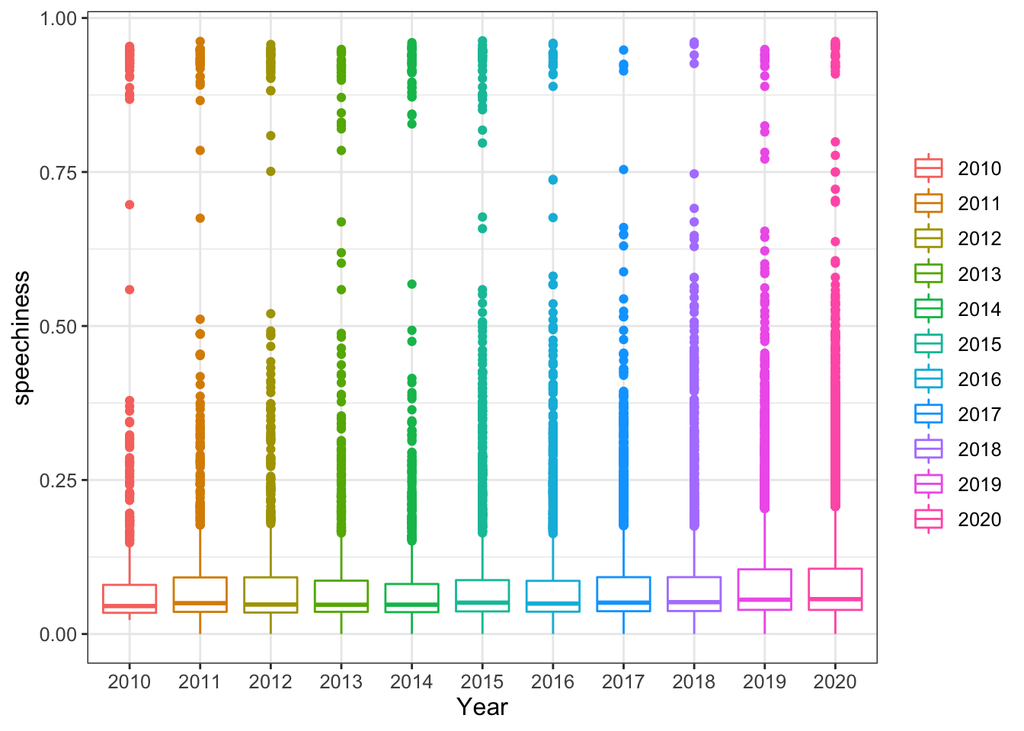

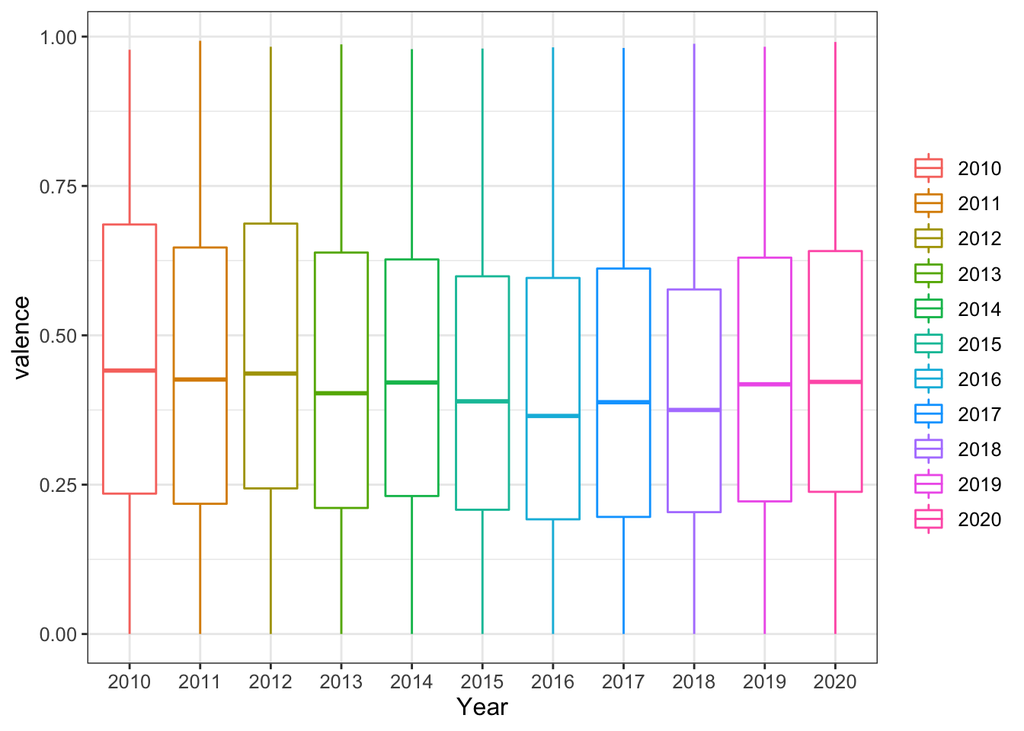

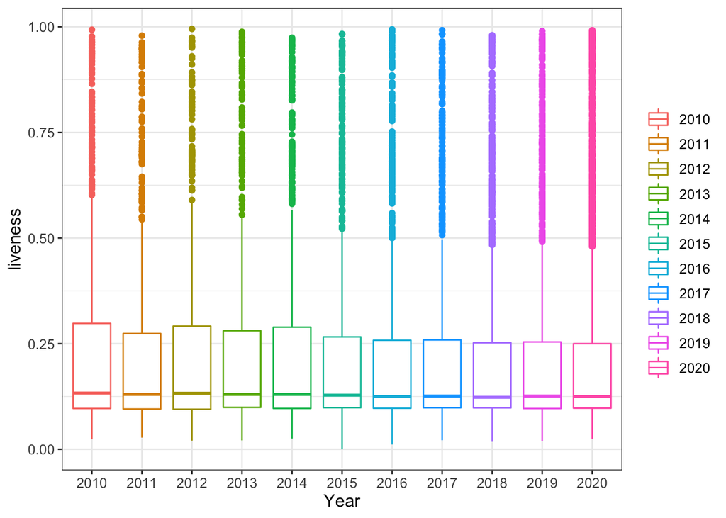

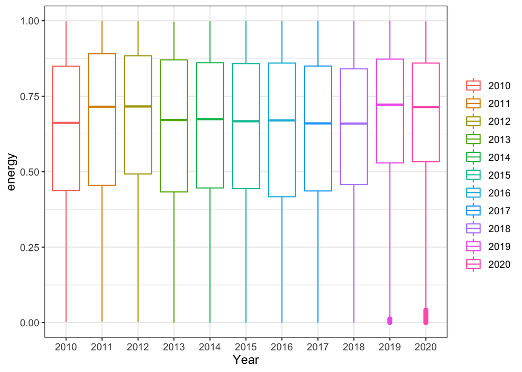

Based on the box plots above, across years, audio features have not changed significantly in the last decade. Yet out of all, danceability changes the most over time.

Now, let’s take a look at the patterns of audio features per genre through a radar plot:

[interactive chart not shown]

Based on this radar graph, we see classical music has high instrumentalness and high acousticness and it has the longest duration in a track on average, which is not surprising. Classical music also has very low loudness and speechiness. Electronic music has the highest energy. R&B music has the highest valence, meaning that R&B music tends to make the listeners feel cheerful and happy. Regarding the speechiness, hip-hop music has the an oustandingly high score while other genres share similar levels of speechiness. This could be explained by the fact that the core of hip-hop genre is rap songs, of which the essential value is lyrics. Hip-hop also has the highest danceability, followed closely by house music. Pop music seems to be more popular than hip-hop music.

Based on the observations above, I am interested in finding mean difference of artist popularity between Pop genre and Hip-hop genre. I am also interested in whether there is mean difference in danceability among different levels of track popularity.

# Statistical Analyses

- Question 1: Is there significant mean difference in artist popularity between Hip-hop genre and Pop genre?

Let’s take a look at the model assumption:

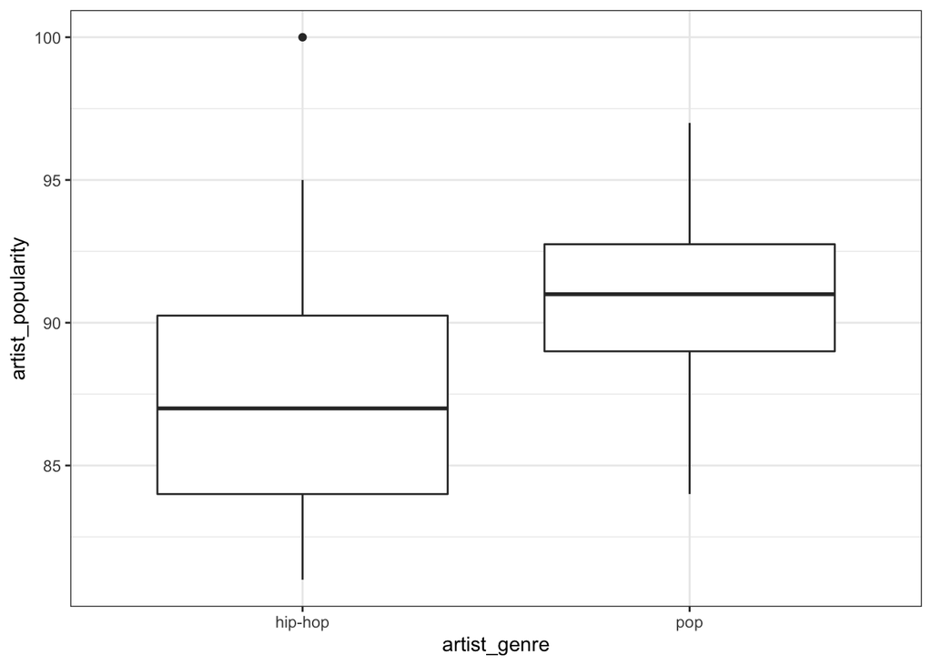

Artist popularity seems normal based on the boxplots above, so there is no need to log the data. Let’s conduct a hypothesis test to find out the mean difference between these two genres:

```
##      p-value          low         high
##  0.004188067 -5.647668460 -1.177006865
```

Based on the t test result above, p value is less than 0.01, so we do not have enough evidence to accept the null hypothesis. We conclude that there is significant mean difference in artist popularity between hip-hop genre and pop genre. The mean difference is estimated to range from approximately 1.18 to 5.65, with pop genre being more popular.

- Question 2: Does the danceability of a song makes a difference in track popularity?

Let’s take a look at the model assumptions:

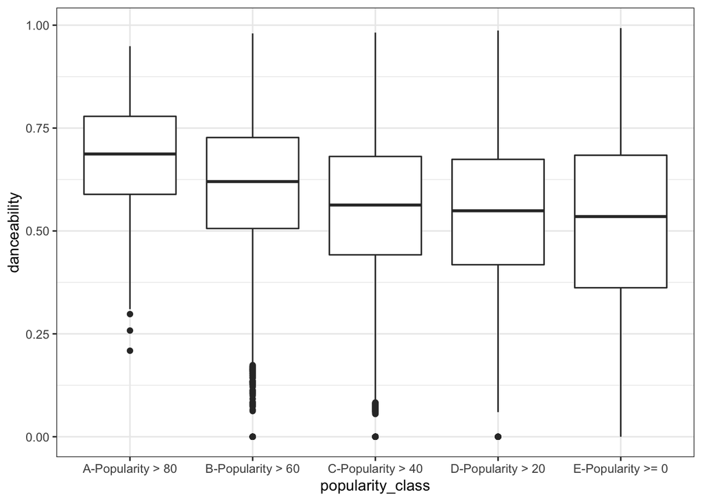

It seems like the more popular a song is, the higher danceability is there in a song. Let’s conduct a hypothesis test:

Null Hypothesis: There is no difference in danceability between a song with popularity over 80 and a song with popularity between 60 and 80. Alternative Hypothesis: There is difference in danceability between a song with popularity over 80 and a song with popularity between 60 and 80.

```
##      p-value          low         high
## 1.487682e-18 5.392672e-02 8.313081e-02
```

P value is significantly small, so we do not have enough evidence to accept the null hypothesis. The mean difference of danceability between a song with popularity over 80 and a song with popularity between 60 and 80 ranges from approximately 0.05 to 0.08. This tells us that when a song tends to make a listener want to dance, this song tends to be popular compared to a song with low danceability.

- Question 3: Do listeners prefer cheerful music?

Based on the correlation plot at the beginning, there is a positive correlation between danceability and valence. Let’s take a look at the behaviors of valence among difference classes of track popularities.

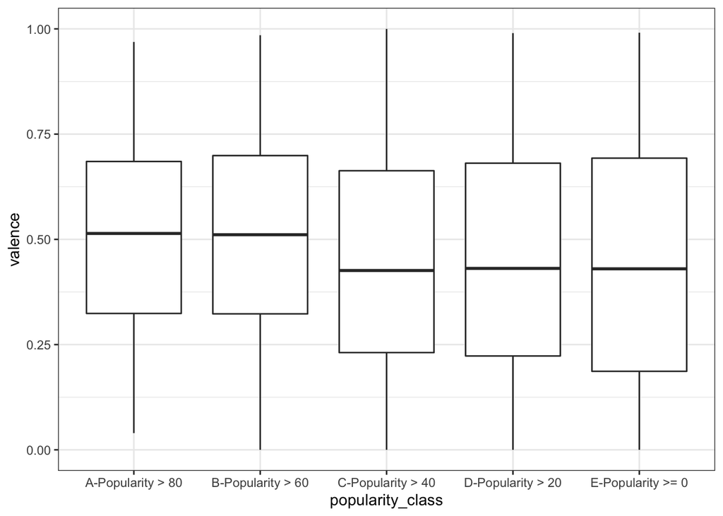

We see that A class and B class do not vary much, but the rest of the classes seem to have lower valence. Let’s conduct a hypothesis test:

Null Hypothesis: There is no difference in valence between a song with popularity over 80 and a song with popularity between 60 and 80. Alternative Hypothesis: There is difference in valence between a song with popularity over 80 and a song with popularity between 60 and 80.

```
##     p-value         low        high
##  0.77658071 -0.02833128  0.02117960
```

P value is quite high, so we fail to reject the null hypothesis. Let’s conduct another hypothesis to analyze the valence between A class and C class of track popularity:

Null Hypothesis: There is no difference in valence between a song with popularity over 80 and a song with popularity between 40 and 60. Alternative Hypothesis: There is difference in valence between a song with popularity over 80 and a song with popularity between 40 and 60.

```
##      p-value          low         high
## 1.803815e-05 2.956328e-02 7.847433e-02
```

# Conclusion

Music trends change over time. While people like different genres of music for different reasons, Hip-hop and Pop are the two leading genres in the current music industry. Both of these genres are likely to make a listener dance, which might be the reason why they bring people’s interest together. In addition, more popular songs seem to convey relatively higher cheerfulness to a listener.

# References

- https://www.businessofapps.com/data/spotify-statistics/#:~:text=Spotify%20currently%20lists%20over%2050,the%20largest%20music%20library%20available.
- https://www.statista.com/statistics/310746/share-music-album-sales-us-genre/#:~:text=In%202018%2C%20hip%2Dhop%20and,U.S.%20in%202018%20was%20jazz.